# Practical Machine Learning - Course Project

Objective : Analyze the data coming from accelerometers present in the activity bands (belt, forearm, arm, and dumbell) of the 6 participants in the study and predict the manner in which they did the exercise. (They were asked to perform barbell lifts correctly and incorrectly in 5 different ways)

Dataset : The data for this project came from the source http://groupware.les.inf.puc-rio.br/har

Training dataset : 19622 rows * 160 cols (including response column ‘classe’)

Holdout sample: 20 records * 160 cols (response column has been replaced by a dummy/surrogate key)

Load the Training & Test/Holdout data files and do a basic inspection of the fields, data types, values etc.

```r
setwd("/home/vulcan/R/Coursera/PracticalMachineLearning-JohnsHopkins")
sensorTrain <- read.csv("pml-training.csv", header = TRUE, sep = ",")
sensorTest <- read.csv("pml-testing.csv", header = TRUE, sep = ",")

head(sensorTrain,10)
```

```
##     X user_name raw_timestamp_part_1 raw_timestamp_part_2   cvtd_timestamp
## 1   1  carlitos           1323084231               788290 05/12/2011 11:23
## 2   2  carlitos           1323084231               808298 05/12/2011 11:23
## 3   3  carlitos           1323084231               820366 05/12/2011 11:23
## 4   4  carlitos           1323084232               120339 05/12/2011 11:23
## 5   5  carlitos           1323084232               196328 05/12/2011 11:23
## 6   6  carlitos           1323084232               304277 05/12/2011 11:23
## 7   7  carlitos           1323084232               368296 05/12/2011 11:23
## 8   8  carlitos           1323084232               440390 05/12/2011 11:23
## 9   9  carlitos           1323084232               484323 05/12/2011 11:23
## 10 10  carlitos           1323084232               484434 05/12/2011 11:23
##    new_window num_window roll_belt pitch_belt yaw_belt total_accel_belt
## 1          no         11      1.41       8.07    -94.4                3
## 2          no         11      1.41       8.07    -94.4                3
## 3          no         11      1.42       8.07    -94.4                3
```

[output cut: 436 more lines]

```r
str(sensorTrain)
```

```
## 'data.frame':    19622 obs. of  160 variables:
##  $ X                       : int  1 2 3 4 5 6 7 8 9 10 ...
##  $ user_name               : Factor w/ 6 levels "adelmo","carlitos",..: 2 2 2 2 2 2 2 2 2 2 ...
##  $ raw_timestamp_part_1    : int  1323084231 1323084231 1323084231 1323084232 1323084232 1323084232 1323084232 1323084232 1323084232 1323084232 ...
##  $ raw_timestamp_part_2    : int  788290 808298 820366 120339 196328 304277 368296 440390 484323 484434 ...
##  $ cvtd_timestamp          : Factor w/ 20 levels "02/12/2011 13:32",..: 9 9 9 9 9 9 9 9 9 9 ...
##  $ new_window              : Factor w/ 2 levels "no","yes": 1 1 1 1 1 1 1 1 1 1 ...
##  $ num_window              : int  11 11 11 12 12 12 12 12 12 12 ...
##  $ roll_belt               : num  1.41 1.41 1.42 1.48 1.48 1.45 1.42 1.42 1.43 1.45 ...
##  $ pitch_belt              : num  8.07 8.07 8.07 8.05 8.07 8.06 8.09 8.13 8.16 8.17 ...
##  $ yaw_belt                : num  -94.4 -94.4 -94.4 -94.4 -94.4 -94.4 -94.4 -94.4 -94.4 -94.4 ...
##  $ total_accel_belt        : int  3 3 3 3 3 3 3 3 3 3 ...
##  $ kurtosis_roll_belt      : Factor w/ 397 levels "","0.000673",..: 1 1 1 1 1 1 1 1 1 1 ...
##  $ kurtosis_picth_belt     : Factor w/ 317 levels "","0.006078",..: 1 1 1 1 1 1 1 1 1 1 ...
##  $ kurtosis_yaw_belt       : Factor w/ 2 levels "","#DIV/0!": 1 1 1 1 1 1 1 1 1 1 ...
```

[output cut: 86 more lines]

```r
nrow(sensorTrain)
```

```
## [1] 19622
```

```r
ncol(sensorTrain)
```

```
## [1] 160
```

### Several columns seem to have *NA*,*NULL*, and other invalid values like *‘#DIV/0!’*

Remove all the columns which have NA and NULL in more than 40% of records

```r
cleanPredSensorTrain <- sensorTrain
which(as.numeric(colSums(is.na(cleanPredSensorTrain)))/nrow(cleanPredSensorTrain) > .4)
```

```
##  [1]  18  19  21  22  24  25  27  28  29  30  31  32  33  34  35  36  50
## [18]  51  52  53  54  55  56  57  58  59  75  76  77  78  79  80  81  82
## [35]  83  93  94  96  97  99 100 103 104 105 106 107 108 109 110 111 112
## [52] 131 132 134 135 137 138 141 142 143 144 145 146 147 148 149 150
```

```r
cleanPredSensorTrain <- cleanPredSensorTrain[,-which(as.numeric(colSums(is.na(cleanPredSensorTrain)))/nrow(cleanPredSensorTrain) > .4)]
cleanPredSensorTrain <- cleanPredSensorTrain[,-which(colSums(cleanPredSensorTrain == '')/nrow(cleanPredSensorTrain) > .4)]
str(cleanPredSensorTrain)
```

```
## 'data.frame':    19622 obs. of  60 variables:
##  $ X                   : int  1 2 3 4 5 6 7 8 9 10 ...
##  $ user_name           : Factor w/ 6 levels "adelmo","carlitos",..: 2 2 2 2 2 2 2 2 2 2 ...
##  $ raw_timestamp_part_1: int  1323084231 1323084231 1323084231 1323084232 1323084232 1323084232 1323084232 1323084232 1323084232 1323084232 ...
##  $ raw_timestamp_part_2: int  788290 808298 820366 120339 196328 304277 368296 440390 484323 484434 ...
##  $ cvtd_timestamp      : Factor w/ 20 levels "02/12/2011 13:32",..: 9 9 9 9 9 9 9 9 9 9 ...
##  $ new_window          : Factor w/ 2 levels "no","yes": 1 1 1 1 1 1 1 1 1 1 ...
##  $ num_window          : int  11 11 11 12 12 12 12 12 12 12 ...
##  $ roll_belt           : num  1.41 1.41 1.42 1.48 1.48 1.45 1.42 1.42 1.43 1.45 ...
##  $ pitch_belt          : num  8.07 8.07 8.07 8.05 8.07 8.06 8.09 8.13 8.16 8.17 ...
##  $ yaw_belt            : num  -94.4 -94.4 -94.4 -94.4 -94.4 -94.4 -94.4 -94.4 -94.4 -94.4 ...
##  $ total_accel_belt    : int  3 3 3 3 3 3 3 3 3 3 ...
##  $ gyros_belt_x        : num  0 0.02 0 0.02 0.02 0.02 0.02 0.02 0.02 0.03 ...
##  $ gyros_belt_y        : num  0 0 0 0 0.02 0 0 0 0 0 ...
##  $ gyros_belt_z        : num  -0.02 -0.02 -0.02 -0.03 -0.02 -0.02 -0.02 -0.02 -0.02 0 ...
```

[output cut: 46 more lines]

### Split this dataset for model estimation & tuning (80/20)

```r
library(caret)
library(AppliedPredictiveModeling)
set.seed(33833)
trainIndex <- createDataPartition(cleanPredSensorTrain$classe, p = .80,list=FALSE,times=1)
cleanTrain <- cleanPredSensorTrain[trainIndex,]
cleanTest  <- cleanPredSensorTrain[-trainIndex,]
```

### Check for predictors with near zero variance. (excluding User Names, Response and time related fields)

```r
nearZeroVar(cleanTrain[,-c(1,2,3,4,5,60)])
```

```
## [1] 1
```

```r
cleanTrain <- cleanTrain[,-c(1,2,3,4,5,6)]
```

### Look for Between-Predictor correlations and plot the correlation matrix.

```r
correlations <- cor(cleanTrain[,-54])
```

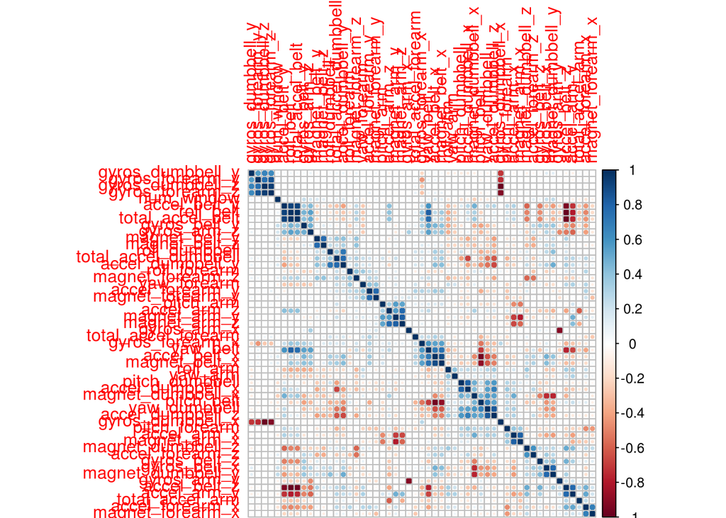

### Eliminate the predictors which have a between predictor correlation beyond a certain threshold.

```r
highCorr <- findCorrelation(correlations,cutoff = .75)
highCorr
```

```
##  [1] 11  2 10 23  5 37  9  3 38 36 39 22 35 24 26 13 49 20 47 46 32
```

```r
length(highCorr)
```

```
## [1] 21
```

```r
cleanTrain <- cleanTrain[,-highCorr]
names(cleanTrain)
```

```
##  [1] "num_window"           "yaw_belt"             "gyros_belt_x"
##  [4] "gyros_belt_y"         "gyros_belt_z"         "magnet_belt_x"
##  [7] "magnet_belt_z"        "roll_arm"             "pitch_arm"
## [10] "yaw_arm"              "total_accel_arm"      "gyros_arm_x"
## [13] "gyros_arm_z"          "magnet_arm_x"         "magnet_arm_z"
## [16] "roll_dumbbell"        "pitch_dumbbell"       "yaw_dumbbell"
## [19] "total_accel_dumbbell" "gyros_dumbbell_y"     "gyros_dumbbell_z"
## [22] "magnet_dumbbell_z"    "roll_forearm"         "pitch_forearm"
## [25] "yaw_forearm"          "total_accel_forearm"  "gyros_forearm_x"
## [28] "accel_forearm_x"      "accel_forearm_z"      "magnet_forearm_x"
## [31] "magnet_forearm_y"     "magnet_forearm_z"     "classe"
```

### Model fit

```r
#set.seed(33833)
#train_control <- trainControl(method="cv", number=5)
#finalM1 <- train(classe ~ ., method = "rf",trControl=train_control, data = cleanTrain,prox = TRUE)
#save(finalM1,file="finalM1.Rda")
load("finalM1.Rda")
finalM1
```

[output not shown]

```r
confusionMatrix(finalM1)
```

```
## Bootstrapped (25 reps) Confusion Matrix
##
## (entries are percentages of table totals)
##
##           Reference
## Prediction    A    B    C    D    E
##          A 28.5  0.1  0.0  0.0  0.0
##          B  0.0 19.4  0.1  0.0  0.0
##          C  0.0  0.0 17.4  0.1  0.0
##          D  0.0  0.0  0.0 16.3  0.0
##          E  0.0  0.0  0.0  0.0 18.2
```

```r
 varImp(finalM1, scale = FALSE)
```

```
## rf variable importance
##
##   only 20 most important variables shown (out of 32)
##
##                      Overall
## num_window            3055.5
## yaw_belt              1366.7
## pitch_forearm         1025.9
## magnet_dumbbell_z      918.3
## magnet_belt_z          642.3
## roll_dumbbell          638.9
## roll_forearm           461.9
## gyros_belt_z           458.7
## total_accel_dumbbell   408.7
## yaw_dumbbell           327.9
## accel_forearm_z        324.3
## roll_arm               283.7
## accel_forearm_x        254.1
## magnet_belt_x          239.8
## magnet_arm_x           219.5
## gyros_dumbbell_y       189.4
## magnet_forearm_z       179.7
## pitch_dumbbell         170.0
## yaw_arm                131.9
## magnet_forearm_y       124.2
```

2. Bootstrap - Resampling

```r
set.seed(33834)
finalM2 <- train(classe ~ ., method = "rf", data = cleanTrain,prox = TRUE)
finalM2
```

```
## Random Forest
##
## 15699 samples
##    32 predictors
##     5 classes: 'A', 'B', 'C', 'D', 'E'
##
## No pre-processing
## Resampling: Bootstrapped (25 reps)
##
## Summary of sample sizes: 15699, 15699, 15699, 15699, 15699, 15699, ...
##
## Resampling results across tuning parameters:
##
##   mtry  Accuracy   Kappa      Accuracy SD   Kappa SD
##    2    0.9937615  0.9921064  0.0011779436  0.0014903762
##   17    0.9972022  0.9964602  0.0006244141  0.0007898034
##   32    0.9939412  0.9923355  0.0019767792  0.0024967166
##
## Accuracy was used to select the optimal model using  the largest value.
## The final value used for the model was mtry = 17.
```

```r
confusionMatrix(finalM2)
```

```
## Bootstrapped (25 reps) Confusion Matrix
##
## (entries are percentages of table totals)
##
##           Reference
## Prediction    A    B    C    D    E
##          A 28.4  0.0  0.0  0.0  0.0
##          B  0.0 19.3  0.0  0.0  0.0
##          C  0.0  0.0 17.4  0.1  0.0
##          D  0.0  0.0  0.0 16.1  0.0
##          E  0.0  0.0  0.0  0.0 18.5
```

```r
#save(finalM1,file="finalM2.Rda")
varImp(finalM2, scale = FALSE)
```

```
## rf variable importance
##
##   only 20 most important variables shown (out of 32)
##
##                      Overall
## num_window            3062.0
## yaw_belt              1354.2
## pitch_forearm         1037.4
## magnet_dumbbell_z      924.7
## magnet_belt_z          617.1
## roll_dumbbell          609.2
## roll_forearm           480.6
## gyros_belt_z           477.0
## total_accel_dumbbell   417.1
## accel_forearm_z        330.9
## yaw_dumbbell           325.9
## roll_arm               269.7
## accel_forearm_x        255.4
## magnet_belt_x          242.3
## magnet_arm_x           209.3
## magnet_forearm_z       198.6
## gyros_dumbbell_y       193.0
## pitch_dumbbell         178.7
## yaw_arm                133.8
## gyros_belt_x           120.6
```

### Predicting against turning sample cleanTest using finalM1 & finalM2

```r
set.seed(12345)
predfinalM1 <- predict(finalM1,cleanTest,type="raw")
cleanTest$predRightM1 <- predfinalM1==cleanTest$classe
table(predfinalM1,cleanTest$classe)
```

```
##
## predfinalM1    A    B    C    D    E
##           A 1116    1    0    1    0
##           B    0  757    1    1    0
##           C    0    1  682    2    0
##           D    0    0    1  639    0
##           E    0    0    0    0  721
```

```r
predfinalM2 <- predict(finalM2,cleanTest,type="raw")
cleanTest$predRight <- predfinalM2==cleanTest$classe
table(predfinalM2,cleanTest$classe)
```

```
##
## predfinalM2    A    B    C    D    E
##           A 1116    1    0    0    0
##           B    0  757    1    1    0
##           C    0    1  682    1    0
##           D    0    0    1  641    0
##           E    0    0    0    0  721
```

### Calculating Out Of Sample Estimation error

```r
missClass = function(values, prediction) {
    sum(prediction != values)/length(values)
}

 Error Rate with Model predfinalM1
errRate_M1 = missClass(cleanTest$classe, predfinalM1)
errRate_M1
```

```
## [1] 0.002039256
```

```r
# Error Rate with Model predfinalM2
errRate_M2 = missClass(cleanTest$classe, predfinalM2)
errRate_M2
```

```
## [1] 0.001529442
```

### Predicting against holdout sample

```r
predfinalML_H <- predict(finalM1,sensorTest,type="raw")
```